# FCA algorithms with the R package fcaR

Working and learning together with fcaR

# 1 How can we use FCA to build a recommender system?

The steps could be as follows:

0. Preprocess data
1. Extract knowledge as implications
2. Use the closure wrt the implications as the engine to provide recommendations
3. What happens when the closure does not provide an useful recommendation?? The Simplification Logic.

# 2 Running example

The aim is to build an automated system using the fcaR package to perform medical diagnosis. We have focused on neurological pathologies since, in recent years, an increasing number of initiatives have appeared to share, curate, and study specific, prevalent brain pathologies. Among these pathologies, schizophrenia is of the highest interest, and public, curated repositories have been released.

| COSAS_1 | COSAS_2 | COSAS_3 | COSAS_4 | COSAS_5 | COSAS_6 | COSAS_7 | FICAL_1 |
| --- | --- | --- | --- | --- | --- | --- | --- |
| absent | absent | absent | absent | absent | absent | absent | absent |
| absent | moderate | moderate | moderate | absent | absent | absent | absent |
| moderate | extreme | absent | absent | absent | absent | absent | mild |
| absent | absent | absent | absent | absent | absent | absent | mild |
| absent | absent | absent | moderate | absent | absent | absent | mild |
| absent | moderate | absent | absent | absent | extreme | absent | absent |

The attributes are:

- COSAS_n

The Simpson-Angus Scale, 7 items to evaluate Parkinsonism-like alterations, related to schizophrenia, in an individual.

- FICAL_n

The Calgary Depression Scale for Schizophrenia, 9 items (attributes) assessing the level of depression in schizophrenia, differentiating between positive and negative aspects of the disease.

- SCIDII_n

The Structured Clinical Interview for DSM-III-R Personality Disorders, with 14 variables related to the presence of signs affecting personality.

- dx_ss

if TRUE, the diagnosis is strict schizophrenia.

- dx_other

it TRUE, the diagnosis is other than schizophrenia, including schizoaffective, bipolar disorder and major depression.

# 3 Preprocess data

Let us scale the context “text/ordinal” -> “grade”

We have done that for you, it is the dataset that is included in the package:

```r
?cobre32
```

# 4 Extract knowledge as implications

Build a formal context object:

```r
fc <- FormalContext$new(cobre32)
```

Use NextClosure to find the Duquenne-Guigues basis:

```r
fc$find_implications()
```

How many implications are there in the basis?

```r
fc$implications$cardinality()
```

```
## [1] 985
```

We can inspect a few of these implications:

```r
fc$implications[5:9]
```

```
## Implication set with 5 implications.
## Rule 1: {SCIDII_22 [0.33]} -> {COSAS_1 [0.5], COSAS_2 [0.5], FICAL_1 [0.33],
##   FICAL_5 [0.33], SCIDII_22, SCIDII_23, dx_ss}
## Rule 2: {SCIDII_21 [0.33]} -> {COSAS_1, COSAS_2, COSAS_3, COSAS_4, COSAS_5,
##   COSAS_6, COSAS_7, FICAL_1, FICAL_2, FICAL_3, FICAL_4, FICAL_5, FICAL_6,
##   FICAL_7, FICAL_8, FICAL_9, SCIDII_10, SCIDII_11, SCIDII_12, SCIDII_13,
##   SCIDII_14, SCIDII_15, SCIDII_16, SCIDII_17, SCIDII_18, SCIDII_19, SCIDII_20,
##   SCIDII_21, SCIDII_22, SCIDII_23, dx_ss, dx_other}
## Rule 3: {SCIDII_20 [0.33]} -> {SCIDII_20 [0.5], dx_ss}
## Rule 4: {SCIDII_20 [0.67], dx_ss} -> {SCIDII_20}
## Rule 5: {SCIDII_19 [0.33]} -> {COSAS_1, COSAS_2, COSAS_3, COSAS_4, COSAS_5,
##   COSAS_6, COSAS_7, FICAL_1, FICAL_2, FICAL_3, FICAL_4, FICAL_5, FICAL_6,
##   FICAL_7, FICAL_8, FICAL_9, SCIDII_10, SCIDII_11, SCIDII_12, SCIDII_13,
##   SCIDII_14, SCIDII_15, SCIDII_16, SCIDII_17, SCIDII_18, SCIDII_19, SCIDII_20,
##   SCIDII_21, SCIDII_22, SCIDII_23, dx_ss, dx_other}
```

Let us save the implications in another variable to avoid long commands from now on:

```r
imps <- fc$implications
```

# 5 Use the closure wrt the implications as the engine to provide recommendations

Let us invent a new individual:

```r
S1 <- Set$new(attributes = fc$attributes,
              COSAS_1 = 1/2, COSAS_2 = 1, COSAS_3 = 1/2,
              COSAS_4 = 1/6, COSAS_5 = 1/2, COSAS_6 = 1)
S1
```

```
## {COSAS_1 [0.5], COSAS_2, COSAS_3 [0.5], COSAS_4 [0.17], COSAS_5 [0.5], COSAS_6}
```

We can compute the closure of this set of attributes using the implications previously computed:

```r
imps$closure(S1)
```

```
## $closure
## {COSAS_1 [0.5], COSAS_2, COSAS_3 [0.5], COSAS_4, COSAS_5 [0.5], COSAS_6, dx_ss}
```

In the closure, there appears `dx_ss`, so with these symptoms, we can conclude the diagnosis of strict schizophrenia.

We could have done the “FCA” closure, that is, using the concept-forming operators of the formal context:

```r
O1 <- fc$extent(S1)
O1
```

```
## {22, 39 [0.5], 66 [0.5], 108}
```

```r
fc$intent(O1)
```

```
## {COSAS_1 [0.5], COSAS_2, COSAS_3 [0.5], COSAS_4, COSAS_5 [0.5], COSAS_6, dx_ss}
```

Or, together, the closure operator:

```r
fc$closure(S1)
```

```
## {COSAS_1 [0.5], COSAS_2, COSAS_3 [0.5], COSAS_4, COSAS_5 [0.5], COSAS_6, dx_ss}
```

Another example:

```r
S2 <- Set$new(attributes = fc$attributes,
              COSAS_4 = 2/3, FICAL_3 = 1/2,
              FICAL_5 = 1/2, FICAL_8 = 1/2)
S2
```

```
## {COSAS_4 [0.67], FICAL_3 [0.5], FICAL_5 [0.5], FICAL_8 [0.5]}
```

We can check the closure:

```r
fc$closure(S2)
```

```
## {COSAS_4, FICAL_1, FICAL_2, FICAL_3, FICAL_5, FICAL_8, dx_other}
```

```r
imps$closure(S2)
```

```
## $closure
## {COSAS_4, FICAL_1, FICAL_2, FICAL_3, FICAL_5, FICAL_8, dx_other}
```

In this case, in the closure set, there appears the attribute `dx_other`, so this would be the desired diagnosis.

A more challenging example:

```r
S3 <- Set$new(attributes = fc$attributes,
              COSAS_2 = 1, COSAS_6 = 1,
              FICAL_1 = 1/3, FICAL_3 = 1/3)
S3
```

```
## {COSAS_2, COSAS_6, FICAL_1 [0.33], FICAL_3 [0.33]}
```

Let us inspect the closure:

```r
fc$closure(S3)
```

```
## {COSAS_2, COSAS_6, FICAL_1 [0.33], FICAL_2 [0.33], FICAL_3 [0.33]}
```

```r
imps$closure(S3)
```

```
## $closure
## {COSAS_2, COSAS_6, FICAL_1 [0.33], FICAL_2 [0.33], FICAL_3 [0.33]}
```

Ok, there is no diagnosis attribute in the closure. What would an expert do? The expert would take into consideration the present attributes and ask for additional symptoms/tests to be able to arrive at a diagnosis.

# 6 What happens when the closure does not provide an useful recommendation? Simplification Logic (SL) to the rescue!

The SL can be used to compute the closure wrt a set of implications, providing a simplified set of implications once the original attributes are taken away, and which is equivalent, in some sense, to the original implication system:

```r
result <- imps$closure(S3, reduce = TRUE)
```

We check the closure:

```r
result$closure
```

```
## {COSAS_2, COSAS_6, FICAL_1 [0.33], FICAL_2 [0.33], FICAL_3 [0.33]}
```

We get the same information as using the classical scheme. But, in addition, we get this simplified set of implications

```r
result$implications
```

[output not shown]

We can narrow the implications by removing redundancies (not needed, but recommended)

```r
result$implications$apply_rules(c('simp', 'rsimp', 'reorder'))
```

```r
result$implications
```

[output not shown]

An expert may be interested only in the rules from which she could derive a diagnosis, so we can simulate that behaviour by filtering the implications and only take into account those in whose RHS there is a diagnosis attribute.

```r
result$implications$filter(rhs = c('dx_ss', 'dx_other'),
                           not_lhs = c('dx_ss', 'dx_other'),
                           drop = TRUE)
```

```
## Implication set with 14 implications.
## Rule 1: {FICAL_5 [0.33]} -> {dx_other}
## Rule 2: {COSAS_3 [0.5]} -> {dx_ss}
## Rule 3: {FICAL_7 [0.33]} -> {dx_ss}
## Rule 4: {FICAL_6 [0.33], FICAL_8 [0.33]} -> {dx_ss}
## Rule 5: {FICAL_4 [0.33], FICAL_8 [0.33]} -> {dx_ss}
## Rule 6: {FICAL_8 [0.33], FICAL_9 [0.33]} -> {dx_ss}
## Rule 7: {COSAS_1 [0.5]} -> {dx_ss}
## Rule 8: {SCIDII_20 [0.33]} -> {dx_ss}
## Rule 9: {SCIDII_16 [0.33]} -> {dx_ss}
## Rule 10: {SCIDII_12 [0.33]} -> {dx_ss}
## Rule 11: {SCIDII_10 [0.5]} -> {dx_ss}
## Rule 12: {SCIDII_18 [0.33]} -> {dx_ss}
## Rule 13: {SCIDII_23 [0.33]} -> {dx_ss}
## Rule 14: {SCIDII_22 [0.33]} -> {dx_ss}
```

What does this mean? In the LHS there are combinations of attributes that, together those present in S3, could lead to a diagnosis. For instance, for our patient S3, having FICAL_5 at least with degree “mild” (0.33) would lead to `dx_other`, whereas having COSAS_3 with degree “moderate”, to `dx_ss`.

Thus, we can build a *conversational* recommender system:

1. Provide as many *symptoms/attributes* as are known.
2. Compute the closure using the simplification logic algorithm.
   - If the closure contains a diagnosis attribute, stop and return it.
   - If it does not, ask the *patient/user* for another attribute among those in the LHS of the reduced implication set. Combine it with the previous ones and repeat step 2.

[figure not shown]

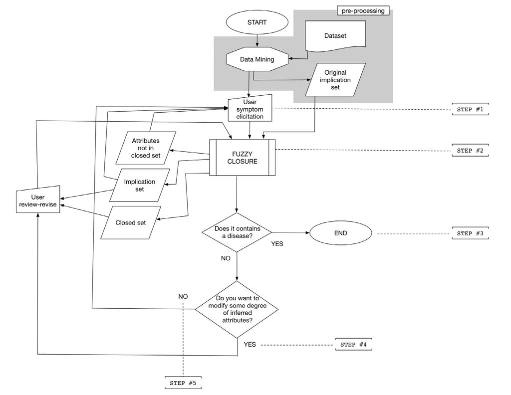

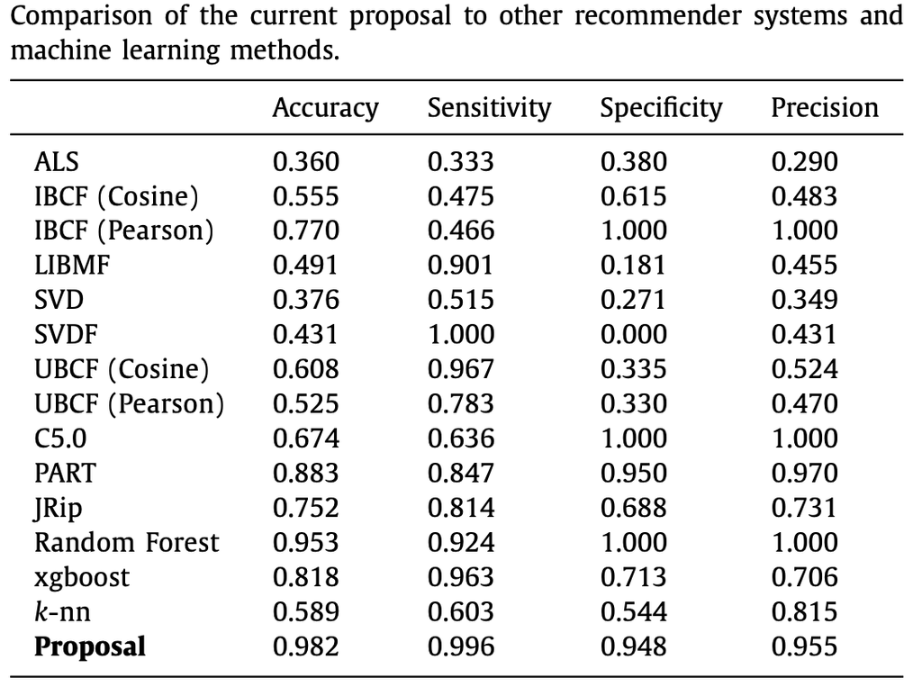